Linear Models: Homework 2

20 November 2021

Student: Khuong Quynh Long

# Questions

Fit two multiple linear regression models with the bird species richness as outcome variable.

1. For model 1, consider the following regressors: AET, PET, PET<sup>2</sup> and AET<sup>2</sup>. You do not have to include interaction effects. Assess the model assumptions and report the results from this data analysis.
1. For model 2, consider the following regressors: AET, PET and PETdiscrete. Include the interaction effect of PET and PETdiscrete. Give an interpretation of the estimated model parameters. Does this model fit well? Make a prediction of the species richness for an area with PET = 400 mm / year and AET = 100 mm /year.

All tests must be performed at the 5% level of significance, and confidence and/or prediction intervals must have a coverage level of 95%.

All data analysis **must** be performed with SAS

# Answers

```sas
/*Set up path and read data*/
%let path = D:\Dropbox\Long\1. Master of Statistics\0. Program\6. Linear model\Homework\data;
libname homework "&path";


proc import datafile="&path\speciesRichness.csv"
        out=homework.speciesRichness(rename = ('Bird.species.richness'n = Bird_species_richness))
        dbms=csv replace;
    guessingrows=max;
    getnames=yes;
run;
```

### Descritive statistics

```sas
/* Print 5 first rows of the data */
proc print data=homework.speciesRichness (obs=5);
    title "Table 1: 5 first rows of the data";
run;
```

Table 1: 5 first rows of the data

| Obs | Id | Lat | Lon | PET | AET | Bird_species_richness | PETdiscrete |
| --- | --- | --- | --- | --- | --- | --- | --- |
| 1 | 30 | 34.5 | 78.5 | 270.33 | 69.76 | 44 | LowEnergy |
| 2 | 31 | 34.5 | 79.5 | 284.81 | 57.68 | 27 | LowEnergy |
| 3 | 32 | 34.5 | 80.5 | 294.53 | 47.72 | 27 | LowEnergy |
| 4 | 52 | 35.5 | 76.5 | 267.32 | 78.68 | 49 | LowEnergy |
| 5 | 53 | 35.5 | 77.5 | 251.14 | 67.9 | 29 | LowEnergy |

```sas
/* Describe continous variables */
proc means data=homework.speciesRichness nmiss n mean median max min;
    var AET PET Bird_species_richness;
    title "Table 2: Describe continous variables";
run;
```

Table 2: Describe continous variables

The MEANS Procedure

| Variable | N Miss | N | Mean | Median | Maximum | Minimum |
| --- | --- | --- | --- | --- | --- | --- |
| AET PET Bird_species_richness | 0 0 0 | 218 218 218 | 117.2884862 575.9108716 203.1513761 | 79.7850000 594.4650000 217.5000000 | 408.3600000 895.2200000 320.0000000 | 18.0100000 251.1400000 25.0000000 |

Figure 1: Distribution of variables

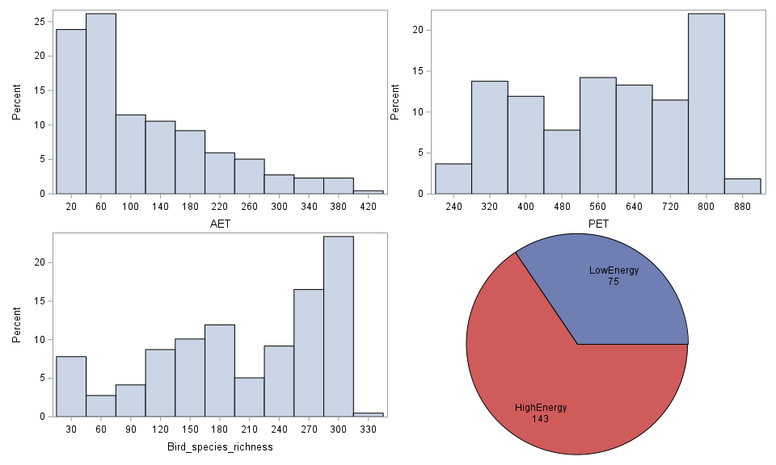

```sas
ods graphics on / width=10in height=6in border=off;
proc template;
    define statgraph multiple_charts_desc;
        begingraph;
        /* entrytitle "Distribution of variables";*/
        /* Define Chart Grid */
            layout lattice / rows = 2 columns = 2;

                /* Chart 1 */
                layout overlay;
                    histogram AET;
                endlayout;

                /* Chart 2 */
                layout overlay;
                    histogram PET;
                endlayout;

                /* Chart 3 */
                layout overlay;
                    histogram Bird_species_richness;
                endlayout;

                /* Chart 4 */
                layout region;
                    piechart category=PETdiscrete;
                endlayout;
            endlayout;
        endgraph;
    end;
run;

proc sgrender data=homework.speciesRichness template=multiple_charts_desc;
    title "Figure 1: Distribution of variables";
run;
ods graphics off
```

Figure 2: Relationship between variables

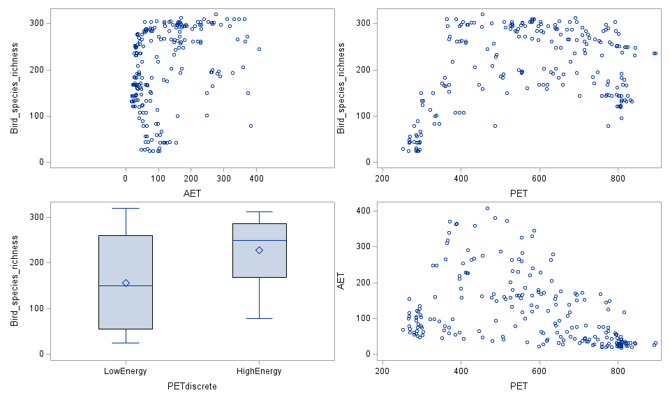

```sas
ods graphics on / width=10in height=6in border=off;
proc template;
    define statgraph multiple_charts_rela;
        begingraph;
        layout lattice / rows = 2 columns = 2;

                /* Chart 1 */
                layout overlay;
                    scatterplot x=AET y=Bird_species_richness;
                endlayout;

                /* Chart 2 */
                layout overlay;
                    scatterplot x=PET y=Bird_species_richness;
                endlayout;

                /* Chart 3 */
                layout overlay;
                    boxplot x=PETdiscrete y=Bird_species_richness;
                endlayout;

                /* Chart 4 */
                layout overlay;
                    scatterplot x=PET y=AET;
                endlayout;
            endlayout;
        endgraph;
    end;
run;

proc sgrender data=homework.speciesRichness template=multiple_charts_rela;
        title "Figure 2: Relationship between variables";
run;
ods graphics off
```

It is noticed that the correlation of AET and PET is not strong, which suggests a low possibility of collinearity in a linear model with these two regressors

```sas
/* proc corr data=homework.speciesRichness;
    var AET;
    with PET;
run; */
```

### Model 1

#### Model defintion

The **Model 1** can be writen as:

$$\textrm{Bird species richness}_i|\textrm{AET, PET } i.i.d. \sim N(\beta_0 + \beta_1AET_i + \beta_2AET_i^2 + \beta_3PET_i + \beta_4PET_i^2, \sigma^2)$$

OR equivalently represented as

$$\textrm{Bird species richness}_i = \beta_0 + \beta_1AET_i + \beta_2AET_i^2 + \beta_3PET_i + \beta_4PET_i^2 + \varepsilon _i$$

With $\varepsilon_i i.i.d. N(0, \sigma^2)$

```sas
* Create variables;
data speciesRichness;
    set homework.speciesRichness;
        AET2 = AET*AET;
        PET2 = PET*PET;
        if PETdiscrete="LowEnergy" then PETdiscrete_01=0;
        else if PETdiscrete="HighEnergy" then PETdiscrete_01=1;
        PET_interaction=PET*PETdiscrete_01;
run;
```

```sas
proc reg data=speciesRichness plots=none;
    model Bird_species_richness = AET AET2 PET PET2 / clb vif alpha=0.05;
    ods select "Parameter Estimates";
    title "Table 3: Parameter estimates of Model 1";
    /*Extract predicted and residuals values for model diagnosis*/
    output out=speciesRichness_pred r=resid p=Bird_species_richness_pred;
run;
```

Table 3: Parameter estimates of Model 1

The REG Procedure

Model: MODEL1

Dependent Variable: Bird_species_richness

| Parameter Estimates Variable | Parameter Estimates DF | Parameter Estimates Parameter Estimate | Parameter Estimates Standard Error | Parameter Estimates t Value | Parameter Estimates Pr > \|t\| | Parameter Estimates Variance Inflation | Parameter Estimates 95% Confidence Limits | Parameter Estimates 95% Confidence Limits |
| --- | --- | --- | --- | --- | --- | --- | --- | --- |
| Intercept | 1 | -377.75825 | 38.25150 | -9.88 | <.0001 | 0 | -453.15822 | -302.35829 |
| AET | 1 | 0.91939 | 0.15824 | 5.81 | <.0001 | 16.73353 | 0.60748 | 1.23131 |
| AET2 | 1 | -0.00177 | 0.00041049 | -4.32 | <.0001 | 14.03603 | -0.00258 | -0.00096252 |
| PET | 1 | 1.74979 | 0.16537 | 10.58 | <.0001 | 70.43514 | 1.42382 | 2.07577 |
| PET2 | 1 | -0.00135 | 0.00015317 | -8.83 | <.0001 | 76.44685 | -0.00165 | -0.00105 |

#### Assess model assumptions

```sas
proc rank data=speciesRichness_pred normal=blom out=speciesRichness_pred;
  var resid;
  ranks resid_quant;
run;
```

Figure 3: Model assumptions diagnosis plots for Model 1

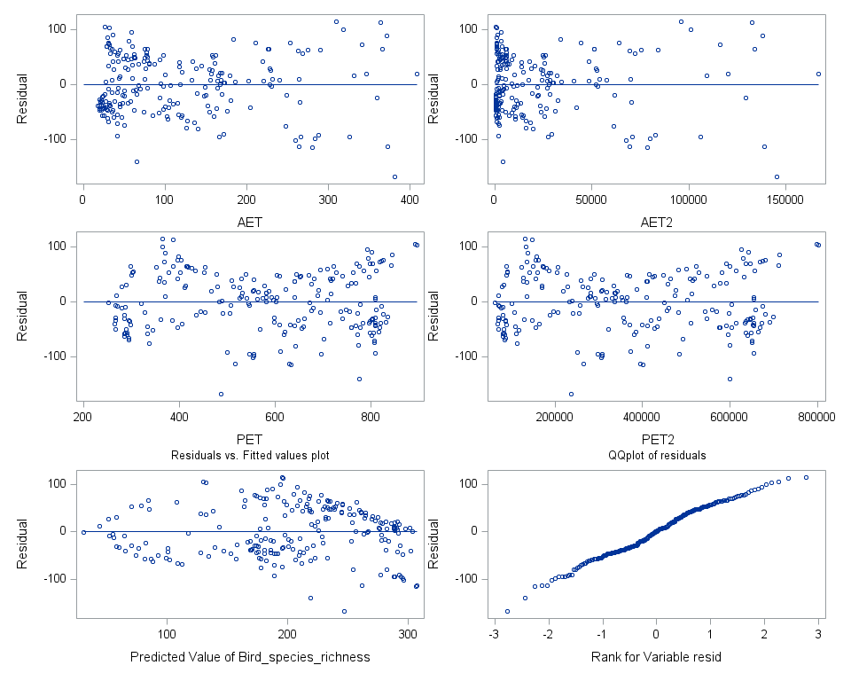

```sas
ods graphics on / width=10in height=8in border=off;
proc template;
    define statgraph model1_diagnos_res;
        begingraph;
            layout lattice / rows = 3 columns = 2;

                /* Chart 1 */
                layout overlay;
                    scatterplot x=AET y=resid;
                    lineparm x=0 y=0 slope=0;
                endlayout;

                /* Chart 2 */
                layout overlay;
                    scatterplot x=AET2 y=resid;
                    lineparm x=0 y=0 slope=0;
                endlayout;

                /* Chart 3 */
                layout overlay;
                    scatterplot x=PET y=resid;
                    lineparm x=0 y=0 slope=0;
                endlayout;

                /* Chart 4 */
                layout overlay;
                    scatterplot x=PET2 y=resid;
                    lineparm x=0 y=0 slope=0;
                endlayout;

                /* Chart 5 */
                layout overlay;
                    entry "Residuals vs. Fitted values plot" / location=outside;
                    scatterplot x=Bird_species_richness_pred y=resid;
                    lineparm x=0 y=0 slope=0;
                endlayout;

                /* Chart 6 */
                layout overlay;
                    entry "QQplot of residuals" / location=outside;
                    scatterplot x=resid_quant y=resid;
                endlayout;
            endlayout;
        endgraph;
    end;
run;

proc sgrender data=work.speciesRichness_pred template=model1_diagnos_res;
    title "Figure 3: Model assumptions diagnosis plots for Model 1";
run;
ods graphics off
```

**Model assumptions**

- *Linearity of the regression model*: Based on residual vs. regressor plots, we can see the average residuals have no systematic pattern as a function of the regressor. Thus, we can conclude that the linearity assumption is met.
- *Homoskedasticity*: Similarly, there are no clear pattern of the variation of residual vs. regressor (except for some data points in the tail of AET), which suggests that the constant-variance assumption is satisfied.
- *Normality of the error term*: Based on QQ-plot of the residuals, the normality assumption does hold since there are no systematic deviations from the diagonal line

🠆 Thus, the assumptions for Model 1 are satisfied

Note: Regarding multicollinearity, although the vif are high for parameters, it is expected since the model includes the quadratic terms.

#### Interpret the parameter estimates

The model 1 can be writen as

$$\textrm{Bird species richness}_i = -377.75 + 0.91939AET_i - 0.00177AET_i^2 + 1.74979PET_i - 0.00135PET_i^2 + \varepsilon _i$$

With $\varepsilon_i i.i.d. N(0, \sigma^2)$

- Conditional on PET, the average change of bird species richness when AET inceases by C units is:

$$0.91939(AET + C) - 0.00177(AET + C)^2 - 0.91939AET + 0.00177AET^2 = 0.91939C - 0.00177C^2 - 0.00354C*AET$$

- Similarly, conditional on AET, the average change of bird species richness when PET inceases by C units is:

$$1.74979(PET + C) - 0.00135(PET + C)^2 - 1.74979PET + 0.00135PET^2 = 1.74979C - 0.00135C^2 - 0.0027C*PET$$

The results are statistically significant at p < 0.001

### Model 2

#### Model defintion

The **Model 2** can be writen as:

$$\textrm{Bird species richness}_i|\textrm{AET, PET } i.i.d. \sim N(\beta_0 + \beta_1AET_i + \beta_2PET_i + \beta_3PET_{discrete_i} + \beta_4PET_i*PET_{discrete_i}, \sigma^2)$$

OR equivalently represented as

$$\textrm{Bird species richness}_i = \beta_0 + \beta_1AET_i + \beta_2PET_i + \beta_3PET_{discrete_i} + \beta_4PET_i*PET_{discrete_i} + \varepsilon _i$$

With $\varepsilon_i i.i.d. N(0, \sigma^2)$

```sas
proc reg data=speciesRichness plots=none;
    model Bird_species_richness = AET PET PETdiscrete_01 PET_interaction / clb vif alpha=0.05;
    ods select "Parameter Estimates";
    title "Table 4: Parameter estimates of Model 2";
    /*Extract predicted and residuals values for model diagnosis*/
    output out=speciesRichness_pred_m2 r=resid p=Bird_species_richness_pred;
run;
```

Table 4: Parameter estimates of Model 2

The REG Procedure

Model: MODEL1

Dependent Variable: Bird_species_richness

| Parameter Estimates Variable | Parameter Estimates DF | Parameter Estimates Parameter Estimate | Parameter Estimates Standard Error | Parameter Estimates t Value | Parameter Estimates Pr > \|t\| | Parameter Estimates Variance Inflation | Parameter Estimates 95% Confidence Limits | Parameter Estimates 95% Confidence Limits |
| --- | --- | --- | --- | --- | --- | --- | --- | --- |
| Intercept | 1 | -226.98864 | 34.92167 | -6.50 | <.0001 | 0 | -295.82498 | -158.15230 |
| AET | 1 | 0.24945 | 0.05292 | 4.71 | <.0001 | 1.66977 | 0.14513 | 0.35376 |
| PET | 1 | 0.96581 | 0.10188 | 9.48 | <.0001 | 23.84907 | 0.76500 | 1.16662 |
| PETdiscrete_01 | 1 | 529.20247 | 55.51995 | 9.53 | <.0001 | 46.85348 | 419.76355 | 638.64138 |
| PET_interaction | 1 | -1.10874 | 0.12374 | -8.96 | <.0001 | 118.58420 | -1.35264 | -0.86483 |

```sas
proc rank data=speciesRichness_pred_m2 normal=blom out=speciesRichness_pred_m2;
  var resid;
  ranks resid_quant;
run;
```

Figure 4: Model assumptions diagnosis plots for Model 2

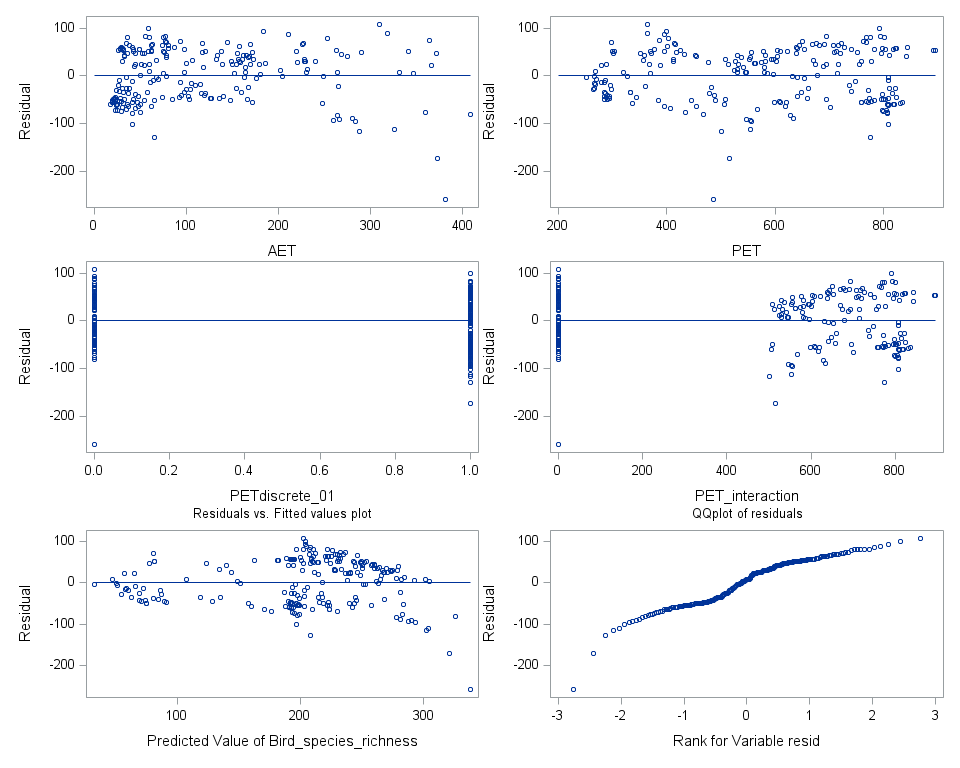

```sas
ods graphics on / width=10in height=8in border=off;
proc template;
    define statgraph model1_diagnos_res2;
        begingraph;
            layout lattice / rows = 3 columns = 2;

                /* Chart 1 */
                layout overlay;
                    scatterplot x=AET y=resid;
                    lineparm x=0 y=0 slope=0;
                endlayout;

                /* Chart 2 */
                layout overlay;
                    scatterplot x=PET y=resid;
                    lineparm x=0 y=0 slope=0;
                endlayout;

                /* Chart 3 */
                layout overlay;
                    scatterplot x=PETdiscrete_01 y=resid;
                    lineparm x=0 y=0 slope=0;
                endlayout;

                /* Chart 4 */
                layout overlay;
                    scatterplot x=PET_interaction y=resid;
                    lineparm x=0 y=0 slope=0;
                endlayout;

                /* Chart 5 */
                layout overlay;
                    entry "Residuals vs. Fitted values plot" / location=outside;
                    scatterplot x=Bird_species_richness_pred y=resid;
                    lineparm x=0 y=0 slope=0;
                endlayout;

                /* Chart 6 */
                layout overlay;
                    entry "QQplot of residuals" / location=outside;
                    scatterplot x=resid_quant y=resid;
                endlayout;
            endlayout;
        endgraph;
    end;
run;

proc sgrender data=work.speciesRichness_pred_m2 template=model1_diagnos_res2;
    title "Figure 4: Model assumptions diagnosis plots for Model 2";
run;
ods graphics off
```

**Model assumptions**

- *Linearity and Homoskedasticity*: Based on residual vs. regressor plots, we can see the average residuals have no systematic pattern as a function of the regressor. There are also no clear pattern of the variation of residual vs. regressor (except for some outliers). Thus, we can conclude that the linearity and homoskedasticity assumptions are met.
- *Normality of the error term*: Based on QQ-plot of the residuals, the normality assumption is considered appropriate as no clear systematic deviations from the diagonal line

🠆 Thus, the assumptions for Model 2 are satisfied

- *Regarding multicollinearity*: The vif of AET is low (1.7), which suggests AET has no multicollinearity problem with other regressors. The vif for PET, PET_descrete, and the interaction term are high, which is expected since the interaction is from PET and PET_descrete

#### Interpret the parameter estimates

The model 2 can be writen as

$$\textrm{Bird species richness}_i = -226.99 + 0.24945AET_i + 0.96581PET_i + 529.20PET_{discrete_i} - 1.10874PET_i*PET_{discrete_i} + \varepsilon _i$$

With $\varepsilon_i i.i.d. N(0, \sigma^2)$

- *Among places with low energy (PETdiscrete = 0)*: conditional on AET, each unit increases in PET is associated with an average of 0.96581 unit increase in bird species richness
- *Among places with high energy (PETdiscrete = 1)*: conditional on AET each unit increases in PET is associated with an average of (0.96581 - 1.10874) unit increase in bird species richness

🠆 In conclusion: conditional on AET, the effect of PET on bird species richness (slope of PET) depends on the level of energy (low/high). Specifically, the effect of PET on bird species richness (slope of PET) in high energy areas is lower by 1.10874, as compared to areas with low energy. The 95% confidence interval from 0.86483 to 1.35264, p-value < 0.001.

```sas
ods graphics on / width=10in height=8in border=off;
proc reg data=speciesRichness plots=none noprint;
    model Bird_species_richness = AET PET PETdiscrete_01 PET_interaction / clb alpha=0.05;
    plot Bird_species_richness*predicted.;
    title "Figure 5: Predicted vs actual values of bird species richness";
run;
ods graphics off
```

The REG Procedure

[figure not shown]

The above plot visualizes the correlation between the predicted and actual values of outcome (bird species richness). We can see the predicted and actual values are strong correlated. The ajusted R-squared of the model is 0.5621, which means 56.21% total variability in the outcome (bird species richness) that is predictable by the fitted regression. The model assuptions are also satisfied (as explained above).

Together, the Model 2 model fits well to the data

#### Make a prediction

Make a prediction of the species richness for an area with PET = 400 mm/year and AET = 100 mm/year

```sas
/*Making new obs for predicting*/
data newobs;
    input AET PET PETdiscrete_01 PET_interaction Bird_species_richness;
    datalines;
    100 400 0 0 .
run;
```

```sas
/*Append to original dataset*/
data speciesRichness2;
set speciesRichness newobs;
run;
```

```sas
/*Making prediction*/
proc reg data=speciesRichness2 noprint;
    model Bird_species_richness = AET PET PETdiscrete_01 PET_interaction / p clm cli alpha=0.05;
    output out=newobs_pred p=Predval lclm=CIlb uclm=CIub lcl=PIlb ucl=PIub  r= residual;
run;
```

```sas
proc print data=newobs_pred(firstobs=219);
    var AET PET PETdiscrete_01 PET_interaction Predval PIlb PIub CIlb CIub;
    title "Table 5: Prediction for  bird species richness in an area with PET = 400 mm/year and AET = 100 mm/year";
run;
```

Table 5: Prediction for bird species richness in an area with PET = 400 mm/year and AET = 100 mm/year

| Obs | AET | PET | PETdiscrete_01 | PET_interaction | Predval | PIlb | PIub | CIlb | CIub |
| --- | --- | --- | --- | --- | --- | --- | --- | --- | --- |
| 219 | 100 | 400 | 0 | 0 | 184.280 | 70.7737 | 297.787 | 166.738 | 201.822 |

The predicted value of bird species richness in an area with PET = 400 mm/year and AET = 100 mm/year (which leads to PETdiscrete = 0 and interaction = 0) is 184 bird species. The 95% Prediction interval is from 71 to 298.

Given the range of bird species richness in the data is from 25 to 320, this 95% PI is very wide. Thus this prediction should be put into a context of very large uncertainty.

Generated by Jupyter notebook; 20-11-2021